# Proyecto “Análisis de los atractivos y/o lugares de interés turístico de la Ciudad”.

Florencia Rocha

28/6/2019

Inroducción "Objetivos: - Conocer los atractivos de la Ciudad identificados por los usuarios (foco en la demanda) - Identificar elementos destacados. - Observar su distribución espacial - Determinar el posicionamiento de los atractivos

Fuente: TripAdvisor fue la web elegida por número de lugares, comentarios actualizados, información disponible.

Proceso Primera Etapa: -Seleccionamos los datos relevantes de 2800 puntos a través de un proceso de webscraping. Se obtuvo la información que desarrollaré a continuación. -Análisis de los atractivos según categoría, definida por la naturaleza del atractivo y el interés del Ente de Turismo. -Presentación de los datos por categoría, distribución en la Ciudad. Ranking de atractivos por cantidad de comentarios y mejor valorados. Posicionamiento de los atractivos en relación a su calificación.

Segunda Etapa -Análisis Sentimental: con los comentarios entre 2012 y 2019. -Análisis de patrones de comportamiento de los usuarios: Según residencia (residentes, nacionales y extranjeros), tipo de viajero, género y rango etario."

```r
library(tidyverse)
library(sf)
```

## Cargo la primer base.

```r
atractivos <- read.csv2 ("C://Users/Flo/Desktop/Curso Ciencia DAtos/dim_atractivos_final.csv",stringsAsFactors = FALSE)
```

## Convierto barrios a factor.

```r
atractivos$barrio <- as.factor(atractivos$barrio)
```

## Arreglos de latitud y longitud (las latitudes y longitudes las toma incorrectas).

```r
atractivos <- atractivos %>%
  mutate(latitud = str_remove_all(latitud, "\\."),
         latitud = paste0(substr(latitud, 1, 3), ".", substr(latitud, 4, nchar(latitud))),
         latitud = as.numeric(latitud),
         longitud = str_remove_all(longitud, "\\."),
         longitud = paste0(substr(longitud, 1, 3), ".", substr(longitud, 4, nchar(longitud))),
         longitud = as.numeric(longitud)) %>%
  filter(between(longitud, -59, -58),
         between(latitud, -35, -34))
```

## Chequeo el arreglo de latitud y longitud

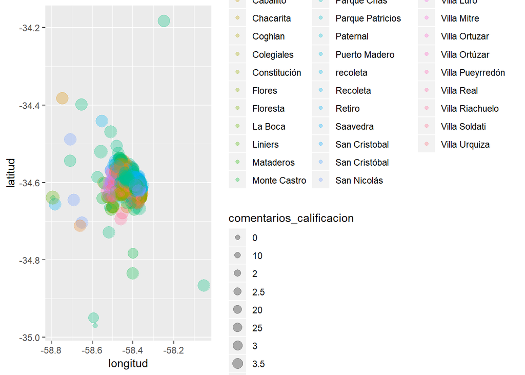

```r
ggplot() +
  geom_point(data = atractivos,
             aes(x = longitud, y = latitud, color = barrio, size = comentarios_calificacion),
             alpha = .3) +
  coord_cartesian()
```

## Arreglo las calificaciones (observo que las calificaciones también están incorrectas. La puntuación de los usuarios debe ir entre 0 - 5 puntos).

```r
atractivos <- atractivos %>%
 mutate(comentarios_calificacion = str_remove_all(comentarios_calificacion, "\\."),
        comentarios_calificacion = as.numeric(comentarios_calificacion),
        comentarios_calificacion = ifelse(comentarios_calificacion > 5,
                                           comentarios_calificacion/10,
                                           comentarios_calificacion))
```

## Veo que estructura tiene el dataframe

```r
str(atractivos)
```

```
## 'data.frame':    1380 obs. of  32 variables:
##  $ id_atractivo            : int  1 2 3 4 5 6 7 8 9 10 ...
##  $ nombre                  : chr  "Teatro Colón" "Recoleta" "Puerto Madero" "San Telmo" ...
##  $ direccion_completa      : chr  "Calle Cerrito 628, Buenos Aires C1010AAN, Argentina" "Junin y Guido, Buenos Aires, Argentina" "Rosario Vera Penaloza, Buenos Aires, Argentina" "Buenos Aires, Argentina" ...
##  $ calle                   : chr  "Calle Cerrito " "Junin y Guido" "Rosario Vera Penaloza" "Buenos Aires" ...
##  $ altura                  : int  628 0 0 0 2966 1790 0 1050 1473 0 ...
##  $ barrio                  : Factor w/ 58 levels "","Agronomía",..: 40 35 33 41 26 35 26 36 35 26 ...
##  $ ciudad                  : chr  "Buenos Aires" "Buenos Aires" "Buenos Aires" "Buenos Aires" ...
##  $ localidad               : chr  "CABA" "CABA" "CABA" "CABA" ...
##  $ provincia               : chr  "Buenos Aires" "Buenos Aires" "Buenos Aires" "Buenos Aires" ...
##  $ pais                    : chr  "Argentina" "Argentina" "Argentina" "Argentina" ...
##  $ latitud                 : num  -34.6 -34.6 -34.6 -34.6 -34.6 ...
##  $ longitud                : num  -58.4 -58.4 -58.4 -58.4 -58.4 ...
##  $ telefono                : chr  "+54 11 4378-7100" "+91 88002 37808" "+91 88002 37808" "" ...
##  $ duracion                : chr  "< 1 hora" "" "1-2 horas" "" ...
```

[output cut: 18 more lines]

## Que contiene?

```r
summary(atractivos)
```

```
##   id_atractivo       nombre          direccion_completa    calle
##  Min.   :   1.0   Length:1380        Length:1380        Length:1380
##  1st Qu.: 345.8   Class :character   Class :character   Class :character
##  Median : 692.5   Mode  :character   Mode  :character   Mode  :character
##  Mean   : 743.9
##  3rd Qu.:1124.2
##  Max.   :1734.0
##
##      altura                 barrio       ciudad
##  Min.   :       0   Palermo    :288   Length:1380
##  1st Qu.:     256   San Nicolás:177   Class :character
##  Median :    1062   Recoleta   :131   Mode  :character
##  Mean   :   85999   Montserrat :124
##  3rd Qu.:    2251   Retiro     :107
##  Max.   :28012967   San Telmo  : 76
##                     (Other)    :477
##   localidad          provincia             pais              latitud
##  Length:1380        Length:1380        Length:1380        Min.   :-34.97
##  Class :character   Class :character   Class :character   1st Qu.:-34.61
##  Mode  :character   Mode  :character   Mode  :character   Median :-34.60
##                                                           Mean   :-34.60
##                                                           3rd Qu.:-34.59
##                                                           Max.   :-34.18
##
##     longitud        telefono           duracion            ranking
##  Min.   :-58.79   Length:1380        Length:1380        Min.   :     1.0
##  1st Qu.:-58.43   Class :character   Class :character   1st Qu.:    73.0
##  Median :-58.40   Mode  :character   Mode  :character   Median :   245.5
##  Mean   :-58.41                                         Mean   : 38014.8
##  3rd Qu.:-58.38                                         3rd Qu.:   602.2
##  Max.   :-58.05                                         Max.   :851851.0
##
##  horario_lunes      horario_martes     horario_miercoles
##  Length:1380        Length:1380        Length:1380
##  Class :character   Class :character   Class :character
##  Mode  :character   Mode  :character   Mode  :character
##
##
##
##
```

[output cut: 25 more lines]

```
##  Min.   :  0.000   Length:1380        Min.   :0.000000
##  1st Qu.:  0.000   Class :character   1st Qu.:0.000000
##  Median :  0.000   Mode  :character   Median :0.000000
##  Mean   :  1.989                      Mean   :0.007971
##  3rd Qu.:  1.000                      3rd Qu.:0.000000
##  Max.   :100.000                      Max.   :1.000000
##
##  direccion_google
##  Length:1380
##  Class :character
##  Mode  :character
##
##
##
##
```

## Qué niveles tiene?

```r
levels(atractivos$barrio)
```

```
##  [1] ""                    "Agronomía"           "Almagro"
##  [4] "Balvanera"           "Barracas"            "Belgrano"
##  [7] "Boca"                "Boedo"               "Caballito"
## [10] "Chacarita"           "Coghlan"             "Colegiales"
## [13] "Constitución"        "Devoto"              "Flores"
## [16] "Floresta"            "La Boca"             "Liniers"
## [19] "Mataderos"           "Monte Castro"        "Montserrat"
## [22] "Nueva Pompeya"       "Nuñez"               "Otro"
## [25] "Otros"               "Palermo"             "Parque "
## [28] "Parque Avellaneda"   "Parque Chacabuco"    "Parque Chas"
## [31] "Parque Patricios"    "Paternal"            "Puerto Madero"
## [34] "recoleta"            "Recoleta"            "Retiro"
## [37] "Saavedra"            "San Cristobal"       "San Cristóbal"
## [40] "San Nicolás"         "San Telmo"           "Urquiza"
## [43] "Versalles"           "Villa Crespo"        "Villa Deboto"
## [46] "Villa del Parque"    "Villa Devoto"        "Villa General Mitre"
## [49] "Villa Lugano"        "Villa Luro"          "Villa Mitre"
## [52] "Villa Ortuzar"       "Villa Ortúzar"       "Villa Pueyrredón "
## [55] "Villa Real"          "Villa Riachuelo"     "Villa Soldati"
## [58] "Villa Urquiza"
```

## Arreglo los barrios (para eso vuelvo a cambiar a cáracter y guardarlo como factor nuevamente. Luego corrijo las inconsistencias).

```r
atractivos$barrio <- as.character(atractivos$barrio)
atractivos[atractivos$barrio=="Villa Deboto" | atractivos$barrio=="Devoto", "barrio"] <- "Villa Devoto"
atractivos[atractivos$barrio=="Boca" , "barrio"] <- "La Boca"
atractivos[atractivos$barrio=="recoleta" , "barrio"] <- "Recoleta"
atractivos[atractivos$barrio=="San Cristobal" , "barrio"] <- "San Cristóbal"
atractivos[atractivos$barrio=="Villa Ortuzar" , "barrio"] <- "Villa Ortúzar"
atractivos[atractivos$barrio=="Urquiza" , "barrio"] <- "Villa Urquiza"
atractivos[atractivos$barrio=="Villa Mitre" , "barrio"] <- "Villa General Mitre"
atractivos[atractivos$barrio=="Parque " , "barrio"] <- "Parque Chas"
atractivos[atractivos$barrio=="Otro", "barrio"] <- "Fuera de Buenos Aires"


atractivos$barrio <- as.factor(atractivos$barrio)
```

## Chequeo los barrios arreglados.

```r
levels(atractivos$barrio)
```

```
##  [1] ""                    "Agronomía"           "Almagro"
##  [4] "Balvanera"           "Barracas"            "Belgrano"
##  [7] "Boedo"               "Caballito"           "Chacarita"
## [10] "Coghlan"             "Colegiales"          "Constitución"
## [13] "Flores"              "Floresta"            "La Boca"
## [16] "Liniers"             "Mataderos"           "Monte Castro"
## [19] "Montserrat"          "Nueva Pompeya"       "Nuñez"
## [22] "Otros"               "Palermo"             "Parque Avellaneda"
## [25] "Parque Chacabuco"    "Parque Chas"         "Parque Patricios"
## [28] "Paternal"            "Puerto Madero"       "Recoleta"
## [31] "Retiro"              "Saavedra"            "San Cristóbal"
## [34] "San Nicolás"         "San Telmo"           "Versalles"
## [37] "Villa Crespo"        "Villa del Parque"    "Villa Devoto"
## [40] "Villa General Mitre" "Villa Luro"          "Villa Ortúzar"
## [43] "Villa Pueyrredón "   "Villa Real"          "Villa Riachuelo"
## [46] "Villa Soldati"       "Villa Urquiza"
```

## Subo la segunda base.

```r
categorias_por_atractivos <- read.csv2("C://Users/Flo/Desktop/Curso Ciencia DAtos/categorias_por_atractivos.csv", stringsAsFactors = FALSE)
```

## Junto las dos primeras bases.

```r
atractivos <- left_join(atractivos, categorias_por_atractivos)
```

## Subo la tercer base (categoría de los atractivos, según tripadvisor).

```r
dim_categorias <- read.csv2 ("C://Users/Flo/Desktop/Curso Ciencia DAtos/dim_categorias.csv",stringsAsFactors = FALSE)
```

## Junto la tercer base

```r
atractivos <- left_join(atractivos, dim_categorias)
```

## Elimino (para el análisis) los atractivos con 2 o menos comentarios

```r
seleccion <- filter(atractivos, comentarios_cantidad  > 2)
head(seleccion)
```

```
##   id_atractivo        nombre
## 1            1  Teatro Colón
## 2            2      Recoleta
## 3            2      Recoleta
## 4            2      Recoleta
## 5            2      Recoleta
## 6            3 Puerto Madero
##                                    direccion_completa
## 1 Calle Cerrito 628, Buenos Aires C1010AAN, Argentina
## 2              Junin y Guido, Buenos Aires, Argentina
## 3              Junin y Guido, Buenos Aires, Argentina
## 4              Junin y Guido, Buenos Aires, Argentina
## 5              Junin y Guido, Buenos Aires, Argentina
## 6      Rosario Vera Penaloza, Buenos Aires, Argentina
##                   calle altura        barrio       ciudad localidad
```

[output cut: 69 more lines]

## Elimino los duplicados

```r
atractivoslimpio <- distinct(seleccion, id_atractivo, .keep_all = TRUE)
```

## Primero, agrupo las categorías de tripadvisor (cat2) a las nuevas categoías definidas por Observatorio Turismo (nueva_cat), para luego crear las categorías finales.

```r
atractivoslimpio$nueva_cat <- atractivoslimpio$cat2
```

## Corrijo los atractivos que están mal categorizados (de cat2 y los reasigno por ID a la nueva_cat que corresponde).

```r
atractivoslimpio[atractivoslimpio$id_atractivo==101 | atractivoslimpio$id_atractivo==230 | atractivoslimpio$id_atractivo==118
        | atractivoslimpio$id_atractivo==370 | atractivoslimpio$id_atractivo==274 | atractivoslimpio$id_atractivo==12 | atractivoslimpio$id_atractivo==491 | atractivoslimpio$id_atractivo==106 | atractivoslimpio$id_atractivo==202 | atractivoslimpio$id_atractivo==1204 | atractivoslimpio$id_atractivo==96 | atractivoslimpio$id_atractivo==230 , "nueva_cat"] <- "Museos"

atractivoslimpio[atractivoslimpio$id_atractivo==121 | atractivoslimpio$id_atractivo==4 | atractivoslimpio$id_atractivo==269 | atractivoslimpio$id_atractivo==2 | atractivoslimpio$id_atractivo==22 | atractivoslimpio$id_atractivo==249 , "nueva_cat"] <- "Barrios"

atractivoslimpio[atractivoslimpio$id_atractivo==830 | atractivoslimpio$id_atractivo==1425 | atractivoslimpio$id_atractivo==52 | atractivoslimpio$id_atractivo==347 | atractivoslimpio$id_atractivo==827 | atractivoslimpio$id_atractivo==828 | atractivoslimpio$id_atractivo==825 | atractivoslimpio$id_atractivo==829 | atractivoslimpio$id_atractivo==834  | atractivoslimpio$id_atractivo==836 | atractivoslimpio$id_atractivo==852 | atractivoslimpio$id_atractivo==844 | atractivoslimpio$id_atractivo==838 | atractivoslimpio$id_atractivo==796 | atractivoslimpio$id_atractivo==843 | atractivoslimpio$id_atractivo==847 | atractivoslimpio$id_atractivo==1160 | atractivoslimpio$id_atractivo==848 | atractivoslimpio$id_atractivo==862 | atractivoslimpio$id_atractivo==850 | atractivoslimpio$id_atractivo==857 | atractivoslimpio$id_atractivo==861 | atractivoslimpio$id_atractivo==871 | atractivoslimpio$id_atractivo==294 , "nueva_cat"] <- "Teatros"

atractivoslimpio[atractivoslimpio$id_atractivo==290 | atractivoslimpio$id_atractivo==171 | atractivoslimpio$id_atractivo==226 | atractivoslimpio$id_atractivo==692 | atractivoslimpio$id_atractivo==466 | atractivoslimpio$id_atractivo==554 | atractivoslimpio$id_atractivo==565 | atractivoslimpio$id_atractivo==85 | atractivoslimpio$id_atractivo==137 | atractivoslimpio$id_atractivo==207 | atractivoslimpio$id_atractivo==180 | atractivoslimpio$id_atractivo==66 | atractivoslimpio$id_atractivo==389 | atractivoslimpio$id_atractivo==726 | atractivoslimpio$id_atractivo==193 | atractivoslimpio$id_atractivo==111 | atractivoslimpio$id_atractivo==793 | atractivoslimpio$id_atractivo==153 | atractivoslimpio$id_atractivo==302 | atractivoslimpio$id_atractivo==75 | atractivoslimpio$id_atractivo==69 | atractivoslimpio$id_atractivo==195 | atractivoslimpio$id_atractivo==728 | atractivoslimpio$id_atractivo==721 | atractivoslimpio$id_atractivo==723 | atractivoslimpio$id_atractivo==216 | atractivoslimpio$id_atractivo==234 | atractivoslimpio$id_atractivo==270 | atractivoslimpio$id_atractivo==307 | atractivoslimpio$id_atractivo==286 | atractivoslimpio$id_atractivo==320 | atractivoslimpio$id_atractivo==346 | atractivoslimpio$id_atractivo==365 | atractivoslimpio$id_atractivo==433 | atractivoslimpio$id_atractivo==321 | atractivoslimpio$id_atractivo==336 | atractivoslimpio$id_atractivo==403 | atractivoslimpio$id_atractivo==650 | atractivoslimpio$id_atractivo==631 | atractivoslimpio$id_atractivo==434 | atractivoslimpio$id_atractivo==371 | atractivoslimpio$id_atractivo==476 | atractivoslimpio$id_atractivo==643 | atractivoslimpio$id_atractivo==335 | atractivoslimpio$id_atractivo==350 | atractivoslimpio$id_atractivo==340 | atractivoslimpio$id_atractivo==366 | atractivoslimpio$id_atractivo==690 | atractivoslimpio$id_atractivo==478 | atractivoslimpio$id_atractivo==713 | atractivoslimpio$id_atractivo==624 | atractivoslimpio$id_atractivo==640 | atractivoslimpio$id_atractivo==62 | atractivoslimpio$id_atractivo==215 | atractivoslimpio$id_atractivo==1289 | atractivoslimpio$id_atractivo==99 | atractivoslimpio$id_atractivo==279 | atractivoslimpio$id_atractivo==362 | atractivoslimpio$id_atractivo==417 | atractivoslimpio$id_atractivo==435 | atractivoslimpio$id_atractivo==439 | atractivoslimpio$id_atractivo==1284 | atractivoslimpio$id_atractivo==486 | atractivoslimpio$id_atractivo==683 | atractivoslimpio$id_atractivo==149  | atractivoslimpio$id_atractivo==55 | atractivoslimpio$id_atractivo==109 ,"nueva_cat"] <- "Plazas y parques"

atractivoslimpio[atractivoslimpio$id_atractivo==922 , "nueva_cat"] <- "Mercados de pulgas y al aire libre"

atractivoslimpio[atractivoslimpio$id_atractivo==498 | atractivoslimpio$id_atractivo==201 | atractivoslimpio$id_atractivo==724 | atractivoslimpio$id_atractivo==106 | atractivoslimpio$id_atractivo==35 | atractivoslimpio$id_atractivo==94 | atractivoslimpio$id_atractivo==689 | atractivoslimpio$id_atractivo==450 | atractivoslimpio$id_atractivo==14 | atractivoslimpio$id_atractivo==460 | atractivoslimpio$id_atractivo==97 | atractivoslimpio$id_atractivo==15 | atractivoslimpio$id_atractivo==722 | atractivoslimpio$id_atractivo==802 | atractivoslimpio$id_atractivo==716 | atractivoslimpio$id_atractivo==474 | atractivoslimpio$id_atractivo==368 | atractivoslimpio$id_atractivo==536 | atractivoslimpio$id_atractivo==19 | atractivoslimpio$id_atractivo==56 | atractivoslimpio$id_atractivo==113 | atractivoslimpio$id_atractivo==236 | atractivoslimpio$id_atractivo==344 | atractivoslimpio$id_atractivo==414 | atractivoslimpio$id_atractivo==357 | atractivoslimpio$id_atractivo==406 | atractivoslimpio$id_atractivo==679 | atractivoslimpio$id_atractivo==553 | atractivoslimpio$id_atractivo==543 | atractivoslimpio$id_atractivo==326 | atractivoslimpio$id_atractivo==782 | atractivoslimpio$id_atractivo==454 | atractivoslimpio$id_atractivo==375 | atractivoslimpio$id_atractivo==228 | atractivoslimpio$id_atractivo==165 | atractivoslimpio$id_atractivo==236 | atractivoslimpio$id_atractivo==674 | atractivoslimpio$id_atractivo==497
                 , "nueva_cat"] <- "Edificios con valor arquitectónico"

atractivoslimpio[atractivoslimpio$id_atractivo==129 , "nueva_cat"] <- "Shoppings"


atractivoslimpio[atractivoslimpio$id_atractivo==104 | atractivoslimpio$id_atractivo==210, "nueva_cat"] <- "Otros"

atractivoslimpio[atractivoslimpio$id_atractivo==415 | atractivoslimpio$id_atractivo==688, "nueva_cat"] <- "transporte de pasajeros"

atractivoslimpio[atractivoslimpio$id_atractivo==86, "nueva_cat"] <- "Edificios gubernamentales"

atractivoslimpio[atractivoslimpio$id_atractivo==43 | atractivoslimpio$id_atractivo==20 | atractivoslimpio$id_atractivo==1286 | atractivoslimpio$id_atractivo==1288 | atractivoslimpio$id_atractivo==1294 | atractivoslimpio$id_atractivo==726 , "nueva_cat"] <- "Estadios y campos deportivos"

atractivoslimpio[atractivoslimpio$id_atractivo==369 | atractivoslimpio$id_atractivo==181 | atractivoslimpio$id_atractivo==64 | atractivoslimpio$id_atractivo==284 | atractivoslimpio$id_atractivo==6, "nueva_cat"] <- "Monumentos y estatuas"

atractivoslimpio[atractivoslimpio$id_atractivo==608 | atractivoslimpio$id_atractivo==110 | atractivoslimpio$id_atractivo==200 | atractivoslimpio$id_atractivo==259 | atractivoslimpio$id_atractivo==145 | atractivoslimpio$id_atractivo==196 | atractivoslimpio$id_atractivo==238 | atractivoslimpio$id_atractivo==159 | atractivoslimpio$id_atractivo==23 | atractivoslimpio$id_atractivo==694 | atractivoslimpio$id_atractivo==33 | atractivoslimpio$id_atractivo==296 | atractivoslimpio$id_atractivo==498 , "nueva_cat"] <- "Lugares religiosos"

atractivoslimpio[atractivoslimpio$id_atractivo==1352 | atractivoslimpio$id_atractivo==915 | atractivoslimpio$id_atractivo==326 | atractivoslimpio$id_atractivo==1365 | atractivoslimpio$id_atractivo==1244 | atractivoslimpio$id_atractivo==1237 | atractivoslimpio$id_atractivo==1363 | atractivoslimpio$id_atractivo==1366 | atractivoslimpio$id_atractivo==1471 | atractivoslimpio$id_atractivo==1367 | atractivoslimpio$id_atractivo==1381 | atractivoslimpio$id_atractivo==1322 | atractivoslimpio$id_atractivo==1353 | atractivoslimpio$id_atractivo==1323 | atractivoslimpio$id_atractivo==826 | atractivoslimpio$id_atractivo==819 | atractivoslimpio$id_atractivo==820 | atractivoslimpio$id_atractivo==821 | atractivoslimpio$id_atractivo==853 | atractivoslimpio$id_atractivo==870 | atractivoslimpio$id_atractivo==1401 | atractivoslimpio$id_atractivo==831 | atractivoslimpio$id_atractivo==1390 | atractivoslimpio$id_atractivo==1395 | atractivoslimpio$id_atractivo==818 | atractivoslimpio$id_atractivo==1396 | atractivoslimpio$id_atractivo==1234 | atractivoslimpio$id_atractivo==824 | atractivoslimpio$id_atractivo==1337 | atractivoslimpio$id_atractivo==1225 | atractivoslimpio$id_atractivo==846 | atractivoslimpio$id_atractivo==1226 | atractivoslimpio$id_atractivo==605 | atractivoslimpio$id_atractivo==636 | atractivoslimpio$id_atractivo==143 | atractivoslimpio$id_atractivo==413 | atractivoslimpio$id_atractivo==1241 , "nueva_cat"] <- "Milongas"

atractivoslimpio[atractivoslimpio$id_atractivo==1122 , "nueva_cat"] <- "Espectaculos y noche"

atractivoslimpio[atractivoslimpio$id_atractivo==330 | atractivoslimpio$id_atractivo==82 | atractivoslimpio$id_atractivo==432 | atractivoslimpio$id_atractivo==627 | atractivoslimpio$id_atractivo==714 | atractivoslimpio$id_atractivo==805 | atractivoslimpio$id_atractivo==898 | atractivoslimpio$id_atractivo==432 | atractivoslimpio$id_atractivo==856 | atractivoslimpio$id_atractivo==591 | atractivoslimpio$id_atractivo==1059 , "nueva_cat"] <- "Centros culturales"

atractivoslimpio[atractivoslimpio$id_atractivo==1110 | atractivoslimpio$id_atractivo==1111 , "nueva_cat"] <- "Casas de tango"


atractivoslimpio[atractivoslimpio$id_atractivo==252 | atractivoslimpio$id_atractivo==211 | atractivoslimpio$id_atractivo==1389 | atractivoslimpio$id_atractivo==1394 | atractivoslimpio$id_atractivo==1429 | atractivoslimpio$id_atractivo==116 | atractivoslimpio$id_atractivo==1725 | atractivoslimpio$id_atractivo==43 | atractivoslimpio$id_atractivo==1387 , "nueva_cat"] <- "Juegos y entretenimiento"
```

## Genero las categorías finales.

```r
atractivoslimpio$cat_final <- ""

atractivoslimpio$nueva_cat <- as.character(atractivoslimpio$nueva_cat)

atractivoslimpio[is.na(atractivoslimpio$nueva_cat),"nueva_cat"] <- "No relevante"

atractivoslimpio <- filter(atractivoslimpio, nueva_cat!="No relevante")

atractivoslimpio[atractivoslimpio$nueva_cat=="Museos" | atractivoslimpio$nueva_cat=="Galerias de arte" | atractivoslimpio$nueva_cat=="Galerías de arte" | atractivoslimpio$nueva_cat=="Museos de arte" | atractivoslimpio$nueva_cat=="Museos especializados" | atractivoslimpio$nueva_cat=="Museos para niños" | atractivoslimpio$nueva_cat=="Museos de historia natural" | atractivoslimpio$nueva_cat=="Museos de historia" | atractivoslimpio$nueva_cat=="Museos de ciencia"  | atractivoslimpio$nueva_cat=="Observatorios y planetarios" , "cat_final"] <- "Museos"

atractivoslimpio[atractivoslimpio$nueva_cat=="Edificios con valor arquitectónico" | atractivoslimpio$nueva_cat=="Edificios gubernamentales" | atractivoslimpio$nueva_cat=="Centros educativos" | atractivoslimpio$nueva_cat=="Lugares educativos" | atractivoslimpio$nueva_cat=="Universidades y escuelas" , "cat_final"] <- "Edificios con valor arquitectónico/histórico"

atractivoslimpio[atractivoslimpio$nueva_cat=="Mercados de pulgas y al aire libre" | atractivoslimpio$nueva_cat=="Calles comerciales" | atractivoslimpio$nueva_cat=="Shoppings" | atractivoslimpio$nueva_cat=="Centros comerciales" | atractivoslimpio$nueva_cat=="Mercados de agricultores" | atractivoslimpio$nueva_cat=="Tiendas de antigüedades" | atractivoslimpio$nueva_cat=="Grandes tiendas" | atractivoslimpio$nueva_cat=="Tiendas especializadas y de regalos" | atractivoslimpio$nueva_cat=="Tiendas de fábricas", "cat_final"] <- "Lugares de compras"

atractivoslimpio[atractivoslimpio$nueva_cat=="Teatros" , "cat_final"] <- "Teatros"

atractivoslimpio[atractivoslimpio$nueva_cat=="Tranvías" | atractivoslimpio$nueva_cat=="transporte de pasajeros" | atractivoslimpio$nueva_cat=="Sistemas de transporte masivo" | atractivoslimpio$nueva_cat=="Ferris" | atractivoslimpio$nueva_cat=="Taxis y otros servicios de traslado", "cat_final"] <- "Transporte de pasajeros"

atractivoslimpio[atractivoslimpio$nueva_cat=="Centros de juego y entretenimiento" | atractivoslimpio$nueva_cat=="Juegos y entretenimiento" | atractivoslimpio$nueva_cat=="Bolos" | atractivoslimpio$nueva_cat=="Juegos de escape" | atractivoslimpio$nueva_cat=="Cines" | atractivoslimpio$nueva_cat=="Más opciones de juego y entretenimiento", "cat_final"] <- "Juego y entreteniento"

atractivoslimpio[atractivoslimpio$nueva_cat=="Lugares religiosos" | atractivoslimpio$nueva_cat=="Iglesias y catedrales" | atractivoslimpio$nueva_cat=="Lugares religiosos y sagrados", "cat_final"] <- "Lugares religiosos"

atractivoslimpio[atractivoslimpio$nueva_cat=="Monumentos y estatuas" | atractivoslimpio$nueva_cat=="Monumentos y estátuas" | atractivoslimpio$nueva_cat=="Monumentos y lugares de interés" | atractivoslimpio$nueva_cat=="Puentes" | atractivoslimpio$nueva_cat=="Cementerios", "cat_final"] <- "Monumentos y estátuas"

atractivoslimpio[atractivoslimpio$nueva_cat=="Espectáculos y noche" | atractivoslimpio$nueva_cat=="Cafés" | atractivoslimpio$nueva_cat=="Piano bar" | atractivoslimpio$nueva_cat=="Centros culturales" | atractivoslimpio$nueva_cat=="Centros cívicos" | atractivoslimpio$nueva_cat=="Bares y discotecas" | atractivoslimpio$nueva_cat=="Clubs y bares de jazz" | atractivoslimpio$nueva_cat=="Bares de vinos" | atractivoslimpio$nueva_cat=="Cabarets" | atractivoslimpio$nueva_cat=="Clubes de comedia" | atractivoslimpio$nueva_cat=="Bares de karaoke" | atractivoslimpio$nueva_cat=="Bares para fumadores" | atractivoslimpio$nueva_cat=="Espectáculos" | atractivoslimpio$nueva_cat=="Clubs y bares de blues" | atractivoslimpio$nueva_cat=="Discotecas y clubes de baile" | atractivoslimpio$nueva_cat=="Clubs y bares gay" , "cat_final"] <- "Experiencias nocturnas"

atractivoslimpio[atractivoslimpio$nueva_cat=="Estadios y campos deportivos" | atractivoslimpio$nueva_cat=="Pistas y carreras de autos"  | atractivoslimpio$nueva_cat=="Campos de juego y estadios" | atractivoslimpio$nueva_cat=="Complejos deportivos" | atractivoslimpio$nueva_cat=="Campos de golf" | atractivoslimpio$nueva_cat=="Campos de tiro", "cat_final"] <- "Estadios y campos deportivos"

atractivoslimpio[atractivoslimpio$nueva_cat=="Barrios" | atractivoslimpio$nueva_cat=="Vecindarios", "cat_final"] <- "Barrios"

atractivoslimpio[atractivoslimpio$nueva_cat=="Otros" | atractivoslimpio$nueva_cat=="Parques temáticos"  | atractivoslimpio$nueva_cat=="Centros de información turística", "cat_final"] <- "Otros"

atractivoslimpio[atractivoslimpio$nueva_cat=="Milongas" | atractivoslimpio$nueva_cat=="Casas de tango" | atractivoslimpio$nueva_cat=="Teatros donde se puede cenar" , "cat_final"] <- "Tango"


atractivoslimpio[atractivoslimpio$nueva_cat=="Experiencias privadas"| atractivoslimpio$nueva_cat=="Otros privados" | atractivoslimpio$nueva_cat=="Clases y talleres" | atractivoslimpio$nueva_cat=="Complejos deportivos"| atractivoslimpio$nueva_cat=="" | atractivoslimpio$nueva_cat=="" | atractivoslimpio$nueva_cat=="Áreas de naturaleza y vida silvestre" | atractivoslimpio$nueva_cat=="Tours de literatura, arte y música" | atractivoslimpio$nueva_cat=="Alquileres de barcos" | atractivoslimpio$nueva_cat=="Deportes acuáticos" | atractivoslimpio$nueva_cat=="Tours turísticos" | atractivoslimpio$nueva_cat=="Tours privados" | atractivoslimpio$nueva_cat=="Tours ecológicos" | atractivoslimpio$nueva_cat=="Paseos en góndola" | atractivoslimpio$nueva_cat=="Cervecerías" | atractivoslimpio$nueva_cat=="Tours en barco" | atractivoslimpio$nueva_cat=="Yoga y pilates" | atractivoslimpio$nueva_cat=="Tours de compras" | atractivoslimpio$nueva_cat=="Tours en bicicletas" | atractivoslimpio$nueva_cat=="Clubes de salud/entrenamiento y gimnasios" | atractivoslimpio$nueva_cat=="Tours por la Ciudad" | atractivoslimpio$nueva_cat=="Tours de bares, discotecas y pubs" | atractivoslimpio$nueva_cat=="Tours históricos" | atractivoslimpio$nueva_cat=="Escapadas de un día" | atractivoslimpio$nueva_cat=="Tours y catas de vinos" | atractivoslimpio$nueva_cat=="Más opciones gastronómicas" | atractivoslimpio$nueva_cat=="Islas" | atractivoslimpio$nueva_cat=="Ranchos" | atractivoslimpio$nueva_cat=="Bodegas y viñedos" | atractivoslimpio$nueva_cat=="Áreas de naturaleza y visa silvestre", "cat_final"] <- "Tours/experiencias privadas"

atractivoslimpio[atractivoslimpio$nueva_cat=="Parques y plazas"| atractivoslimpio$nueva_cat=="Jardines" | atractivoslimpio$nueva_cat=="Parques"| atractivoslimpio$nueva_cat=="Plazas" | atractivoslimpio$nueva_cat=="Masas de agua" | atractivoslimpio$nueva_cat=="Plazas y parques", "cat_final"] <- "Parques y plazas"
```

## Corrijo la calificación nuevamente (la que viene por defaul no es exacta, la re-calculo en base a la proporción de comentarios entre excelente y horrible).

```r
atractivoslimpio <- atractivoslimpio %>%
  mutate(comentarios_calificacion=(cantidad_excelente *5 +  cantidad_muybueno *4    + cantidad_normal *3 +  cantidad_malo *2    + cantidad_horrible *1)/(cantidad_excelente + cantidad_normal + cantidad_malo + cantidad_muybueno + cantidad_horrible))
```

## Borrar las tablas anteriores (para que funcione mejor la pc).

```r
rm(atractivos)
rm(seleccion)
rm(categorias_por_atractivos)
rm(dim_categorias)
```

## Cantidad de comentarios por barrio. Utilizando pipe

```r
cometariosporbarrio <- group_by(atractivoslimpio, barrio)%>%
summarise (totalbarrio = sum(comentarios_cantidad))
```

```r
comentariosporbarrio <- group_by(atractivoslimpio, barrio)%>%
summarise (totalbarrio = sum(comentarios_cantidad))


head (comentariosporbarrio)
```

```
## # A tibble: 6 x 2
##   barrio    totalbarrio
##   <fct>           <int>
## 1 Agronomía          65
## 2 Almagro          1354
## 3 Balvanera        9922
## 4 Barracas         5606
## 5 Belgrano         6283
## 6 Boedo            1595
```

## Visualización

Atractivos por cantidad de comentario y calificación

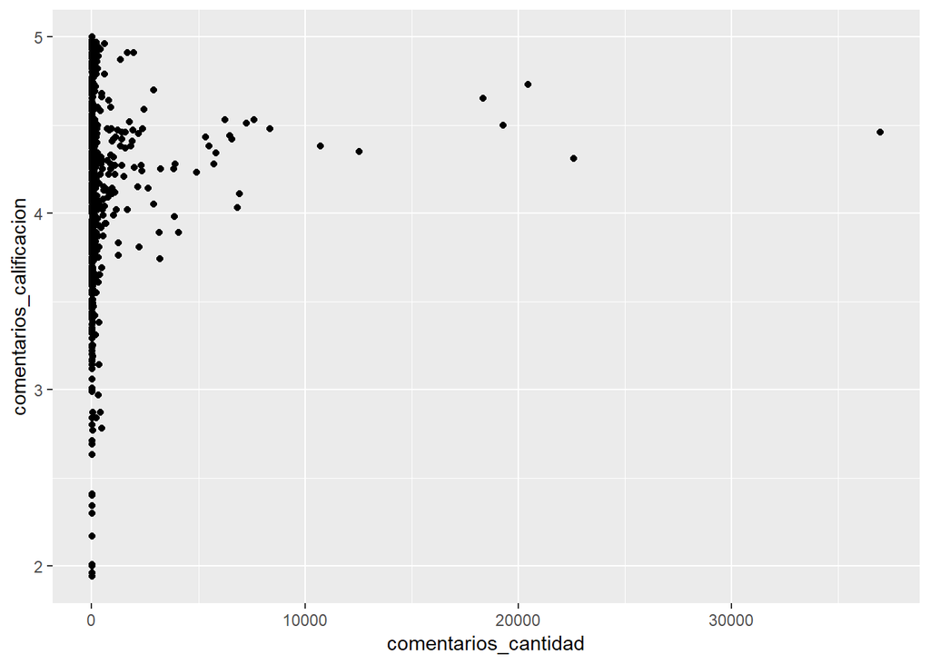

```r
ggplot(atractivoslimpio) + geom_point(aes(x = comentarios_cantidad, y = comentarios_calificacion))
```

## Le asigno color a cada categoría.

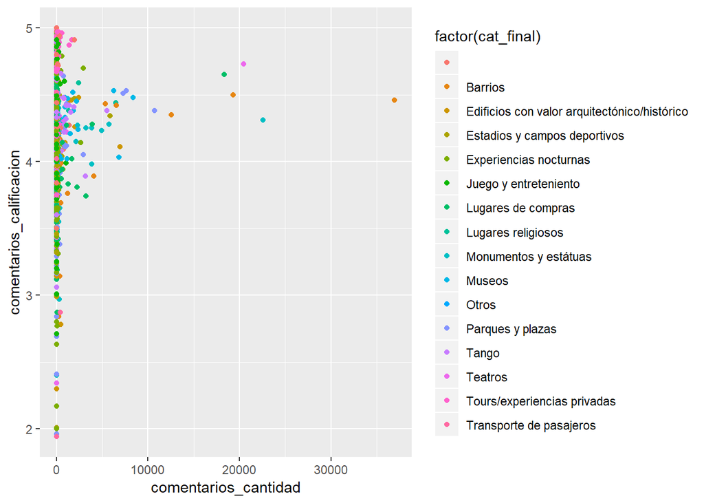

```r
ggplot(atractivoslimpio) +
    geom_point(aes(x = comentarios_cantidad, y = comentarios_calificacion, color = factor(cat_final)))
```

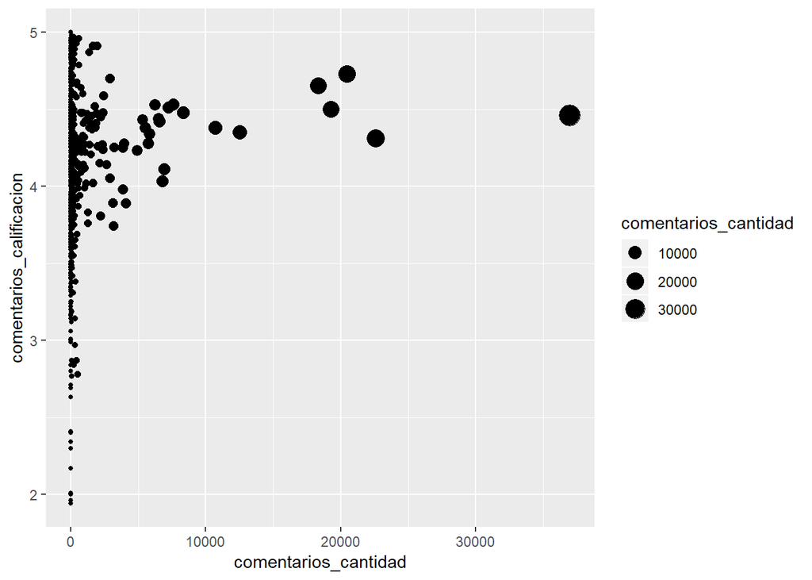

```r
ggplot(atractivoslimpio) +
    geom_point(aes(x = comentarios_cantidad, y = comentarios_calificacion, size = comentarios_cantidad))
```

## Análisis por categoría final.

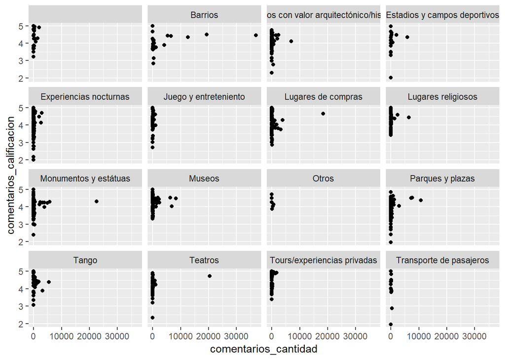

```r
ggplot(atractivoslimpio) +
    geom_point(aes(x = comentarios_cantidad, y = comentarios_calificacion)) +
    facet_wrap(~cat_final)
```

## Gráfico de barras para ver cantidad de comentarios por barrio.

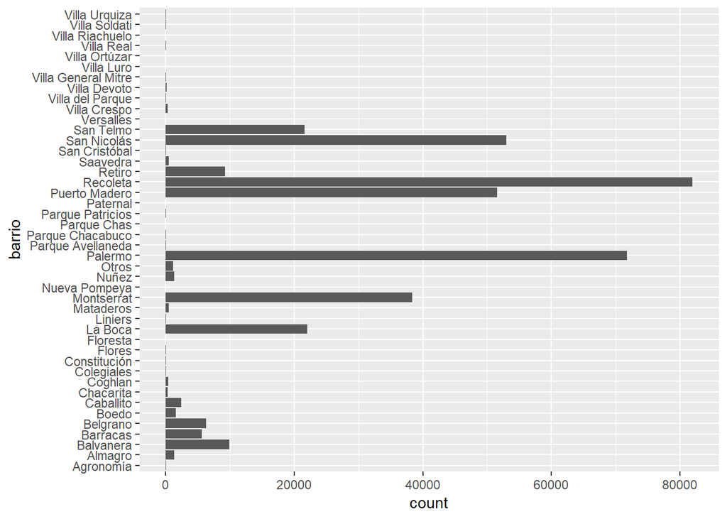

```r
ggplot(atractivoslimpio) +
    geom_bar(aes(x = barrio, weight = comentarios_cantidad)) +
    coord_flip()
```

## Gráfico: Barrios por cantidad de cometarios y categoria.

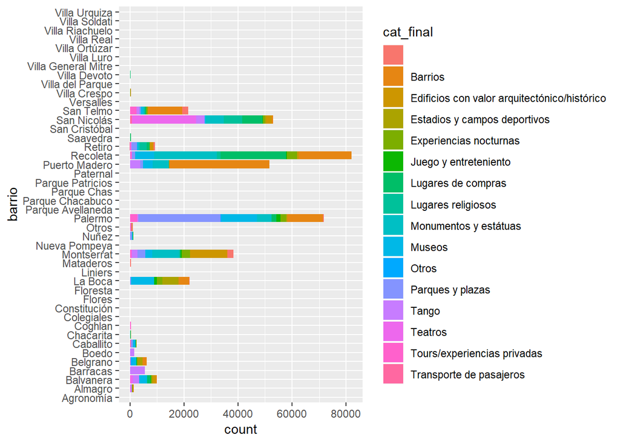

```r
ggplot(atractivoslimpio) +
    geom_bar(aes(x = barrio, weight = comentarios_cantidad, fill = cat_final)) +
    coord_flip()
```

## Gráfico mejorado.

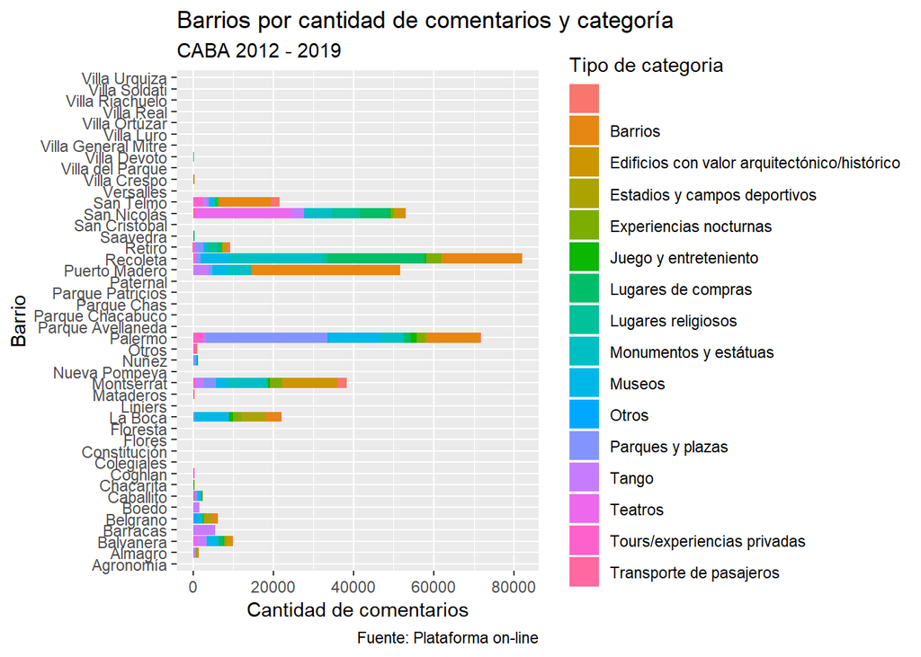

```r
ggplot(atractivoslimpio) +
    geom_bar(aes(x = barrio, weight = comentarios_cantidad, fill = cat_final)) +
    coord_flip() +
    labs(title = "Barrios por cantidad de comentarios y categoría",
         subtitle = "CABA 2012 - 2019",
         caption = "Fuente: Plataforma on-line",
         x = "Barrio",
         y = "Cantidad de comentarios",
         fill = "Tipo de categoria")
```

## Importo mapa de la ciudad

```r
 barrios <-
  st_read("https://data.buenosaires.gob.ar/dataset/19/resource/1c3d185b-fdc9-474b-b41b-9bd960a3806e/download/barrios.geojson")
summary(barrios)
```

```
##        BARRIO       COMUNA               PERIMETRO                 AREA
##  AGRONOMIA: 1   1      : 6   10021.45966480549: 1   1232275.092474457: 1
##  ALMAGRO  : 1   10     : 6   10165.62712936149: 1   1279951.372561846: 1
##  BALVANERA: 1   15     : 6   10597.25280900626: 1   1334146.08283464 : 1
##  BARRACAS : 1   11     : 4   10674.41646756023: 1   1385411.513739759: 1
##  BELGRANO : 1   12     : 4   10990.96447148555: 1   1406833.595801687: 1
##  BOCA     : 1   4      : 4   11124.63579209356: 1   15772496.3315    : 1
##  (Other)  :42   (Other):18   (Other)          :42   (Other)          :42
##           geometry
##  POLYGON      :48
##  epsg:4326    : 0
##  +proj=long...: 0
##
##
##
##
```

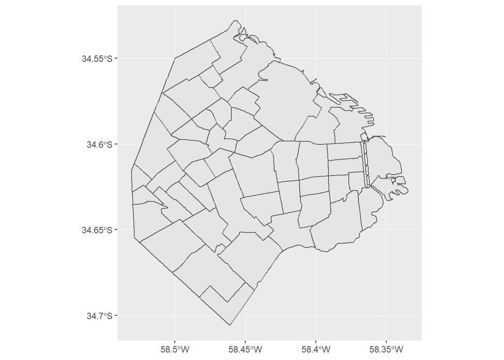

```r
ggplot() + geom_sf(data = barrios)
```

## Uno la base con el mapa (primero unifico variable Barrio para poder juntar la base).

```r
colnames(atractivoslimpio)[colnames (atractivoslimpio)=="barrio"]<- "BARRIO"
atractivoslimpio$BARRIO <- toupper (atractivoslimpio$BARRIO)

barrios_geo <- barrios %>%
  left_join(atractivoslimpio)
head(barrios_geo)
```

```
## Simple feature collection with 6 features and 41 fields
## geometry type:  POLYGON
## dimension:      XY
## bbox:           xmin: -58.46623 ymin: -34.59828 xmax: -58.43794 ymax: -34.57874
## epsg (SRID):    4326
## proj4string:    +proj=longlat +datum=WGS84 +no_defs
##      BARRIO COMUNA        PERIMETRO              AREA id_atractivo
## 1 CHACARITA     15 7725.69522770465 3118100.972396454          181
## 2 CHACARITA     15 7725.69522770465 3118100.972396454          197
## 3 CHACARITA     15 7725.69522770465 3118100.972396454          250
## 4 CHACARITA     15 7725.69522770465 3118100.972396454          352
## 5 CHACARITA     15 7725.69522770465 3118100.972396454          365
## 6 CHACARITA     15 7725.69522770465 3118100.972396454          377
##                                         nombre
## 1                   Cementerio de la Chacarita
```

[output cut: 96 more lines]

## Genero el mapa para ubicar los atractivos.

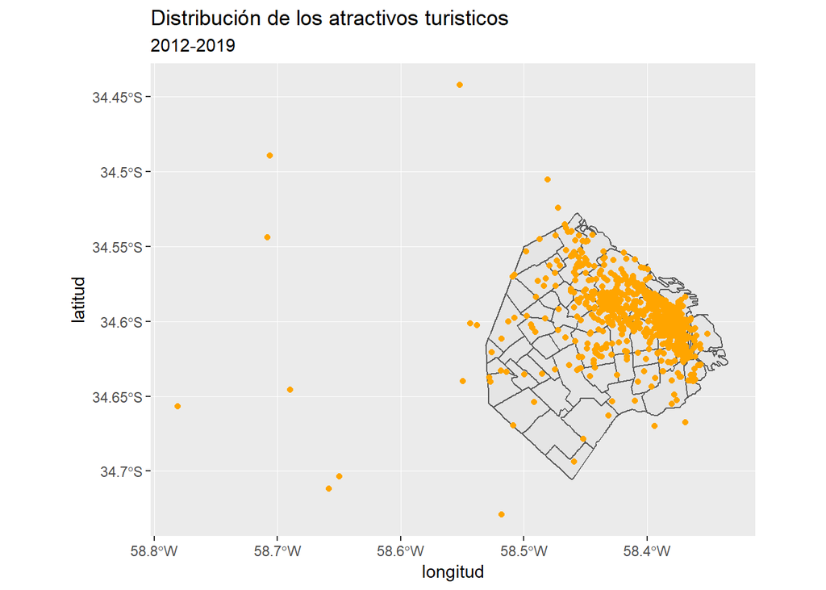

```r
atractivoslimpio %>%
  filter(latitud < -34.4 & latitud > -34.75) %>%
ggplot() +
    geom_sf(data = barrios) +
    geom_point(aes (x = longitud, y = latitud) , color = "orange") +
    labs(title = "Distribución de los atractivos turisticos",
         subtitle = "2012-2019")
```

##Conclusiones:

###Personal: No logré alcanzar los objetivos de los puntos requeridos, el tiempo que me insumió la corrección de cada uno de los pasos a medida que iba avanzando fue tal que me fue imposible llegar y me resulta entre otras cosas muy frustrante!. Observo aún problemas en la base, si bien el código corre bien, la organización del paso de las categorías me genera muchas dudas entre otras cosas. El desarrollo de este tema es de sumo interés para mí como para el área. Espero obtener comentarios de ustedes y seguir avanzando!!.